# MATH 4753 Project 2

## 6.9 Testing another model for comparison/Validation

Now we need to determine if a linear model is the only option to test. To do this I will test the results against a quadratic curve.

### 6.9.1 Fitting a quadratic to the points

$$y_i= \beta_0 + \beta_1x_i +\beta_2x_i^2\\$$

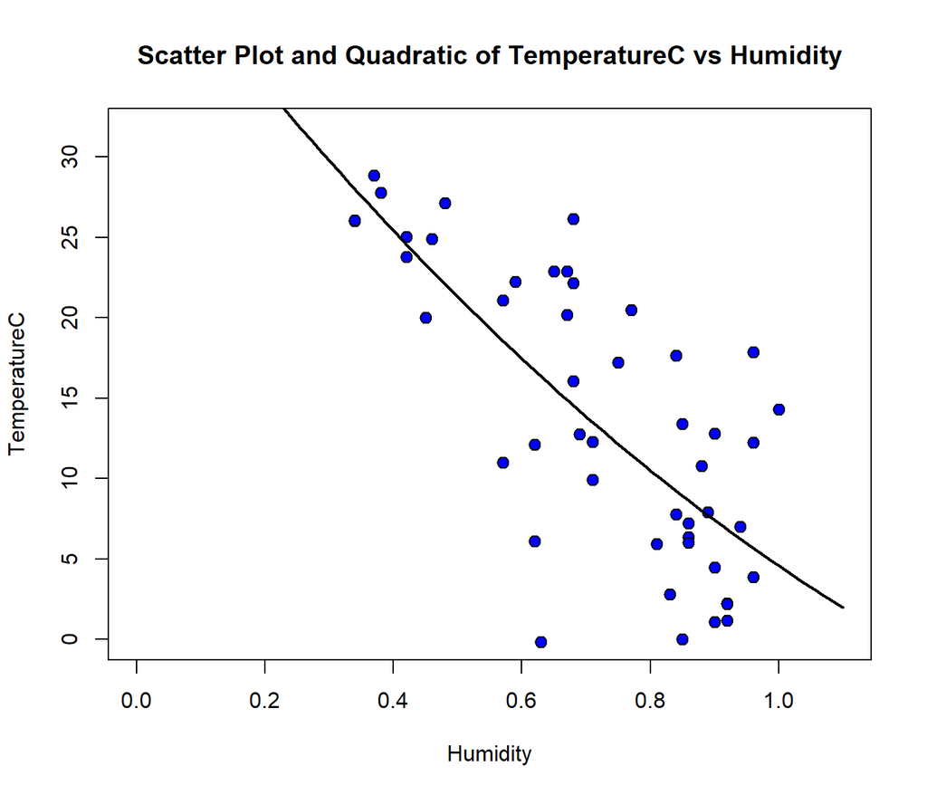

```r
quad.lm=lm(TemperatureC~Humidity + I(Humidity^2),data=weather)

plot(TemperatureC~Humidity,bg="Blue",pch=21,cex=1.2,
   ylim=c(0,1.1*max(TemperatureC)),xlim=c(0,1.1*max(Humidity)),main="Scatter Plot and Quadratic of TemperatureC vs Humidity",data=weather)
myplot = function(x){quad.lm$coef[1] + quad.lm$coef[2]*x + quad.lm$coef[3]*x^2}
curve(myplot, lwd = 2, add = TRUE)
```

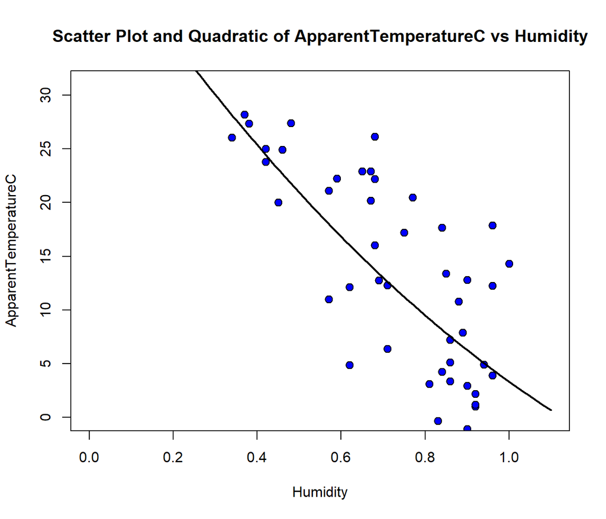

```r
quad2.lm=lm(ApparentTemperatureC~Humidity + I(Humidity^2),data=weather)

plot(ApparentTemperatureC~Humidity,bg="Blue",pch=21,cex=1.2,
   ylim=c(0,1.1*max(ApparentTemperatureC)),xlim=c(0,1.1*max(Humidity)),main="Scatter Plot and Quadratic of ApparentTemperatureC vs Humidity",data=weather)
myplot = function(x){quad2.lm$coef[1] + quad2.lm$coef[2]*x + quad2.lm$coef[3]*x^2}
curve(myplot, lwd = 2, add = TRUE)
```

The quadratic did not give very different results. The graph still looks largely linear but we will wait on further analysis to make a final decision.

```r
#Control
quad1.fit = c(weatherCont.fit)
#Experiment
quad2.fit = c(weatherExp.fit)
```

## 6.10 Summarize the models

First the Control Model:

```r
quad.lm=lm(TemperatureC~Humidity + I(Humidity^2),data=weather.df)

summary(quad.lm)
```

```
##
## Call:
## lm(formula = TemperatureC ~ Humidity + I(Humidity^2), data = weather.df)
##
## Residuals:
##     Min      1Q  Median      3Q     Max
## -2.9046 -1.6020  0.2689  1.1766  3.3584
##
## Coefficients:
##               Estimate Std. Error t value Pr(>|t|)
## (Intercept)      81.49      37.36   2.181   0.0342 *
## Humidity       -168.31      88.91  -1.893   0.0645 .
## I(Humidity^2)    90.63      52.66   1.721   0.0918 .
## ---
## Signif. codes:  0 '***' 0.001 '**' 0.01 '*' 0.05 '.' 0.1 ' ' 1
##
## Residual standard error: 1.846 on 47 degrees of freedom
## Multiple R-squared:  0.2808, Adjusted R-squared:  0.2502
## F-statistic: 9.177 on 2 and 47 DF,  p-value: 0.000432
```

The summary tells us the betas for the control Model measuring Temperature v Humidity

$$\beta_0=81.49\\
\beta_1=-168.31\\
\beta_2=90.63\\$$
As well as the Multiple R squared and the adjusted R squared which we will need to compare calculations to determine if linear or quadratic best fits the data.

But first we will take the summary of our other model we have been checking. Again, this model will compare the Apparent Temperature and the humidity.

```r
quad2.lm=lm(ApparentTemperatureC~Humidity + I(Humidity^2),data=weather.df)

summary(quad2.lm)
```

```
##
## Call:
## lm(formula = ApparentTemperatureC ~ Humidity + I(Humidity^2),
##     data = weather.df)
##
## Residuals:
##     Min      1Q  Median      3Q     Max
## -3.9768 -2.2010  0.3096  1.3638  7.0555
##
## Coefficients:
##               Estimate Std. Error t value Pr(>|t|)
## (Intercept)      81.14      52.81   1.537    0.131
## Humidity       -179.35     125.66  -1.427    0.160
## I(Humidity^2)    98.82      74.43   1.328    0.191
##
## Residual standard error: 2.609 on 47 degrees of freedom
## Multiple R-squared:  0.1288, Adjusted R-squared:  0.09175
## F-statistic: 3.475 on 2 and 47 DF,  p-value: 0.03913
```

The summary tells us the betas for the experimental Model measuring ApparentTemperature v Humidity

$$\beta_0=81.14\\
\beta_1=-179.35\\
\beta_2=98.82\\$$

As well as the Multiple R squared and the adjusted R squared which we will need to compare calculations to determine if linear or quadratic best fits the data.

## 6.11 Calculating the CI for parameter estimates

```r
#Control model
ciReg(quad.lm, conf.level=0.95, print.out=TRUE)
```

```
##               95 % C.I.lower    95 % C.I.upper
## (Intercept)          6.32575         156.64892
## Humidity          -347.16658          10.54748
## I(Humidity^2)      -15.31119         196.57753
```

```r
#Experimental Model
ciReg(quad2.lm, conf.level=0.95, print.out=TRUE)
```

```
##               95 % C.I.lower    95 % C.I.upper
## (Intercept)        -25.09093         187.37006
## Humidity          -432.13923          73.44008
## I(Humidity^2)      -50.91401         248.56137
```

## 6.12 Equation of the fitted line

$$\textsf{Equation for the Control}\\
\beta_0 + \beta_1x_1+\beta_2 x_1^2 = (81.49)+(-168.31)(x) + (90.63)x^2\\
\textsf{Equation for the Experiment}\\
\beta_0 + \beta_1x_1+\beta_2 x_1^2 = (81.14)+(-179.35)(x) + (98.82)x^2\\$$

## 6.13 Comparison of Models

### 6.13.1 Making Predictions using the Models

The goal is to predict the ApparentTemperature when the humidity is at 0.4, 0.7 and 0.9 and compare it to the actual temperature at 0.4, 0.7, and 0.9.

```r
perceivedlm=predict(weatherExp.lm, data.frame(Humidity=c(0.4,0.7,0.9)))
perceivedlm
```

```
##         1         2         3
## 24.804738 13.580322  6.097378
```

```r
actuallm=predict(weatherCont.lm, data.frame(Humidity=c(0.4,0.7,0.9)))
actuallm
```

```
##         1         2         3
## 24.949168 14.342973  7.272175
```

```r
actualqd=predict(quad.lm, data.frame(Humidity=c(0.4,0.7,0.9)))
actualqd
```

```
##         1         2         3
## 28.664825  8.080906  3.421610
```

```r
perceivedqd=predict(quad2.lm, data.frame(Humidity=c(0.4,0.7,0.9)))
perceivedqd
```

```
##         1         2         3
## 25.211523  4.018466 -0.227870
```

### 6.13.2 Comparing the R Values

```r
summary(weatherExp1.lm)
```

```
##
## Call:
## lm(formula = Humidity ~ ApparentTemperatureC, data = weather)
##
## Residuals:
##      Min       1Q   Median       3Q      Max
## -0.33159 -0.09906  0.00301  0.08472  0.30429
##
## Coefficients:
##                       Estimate Std. Error t value Pr(>|t|)
## (Intercept)           0.898809   0.030892  29.095  < 2e-16 ***
## ApparentTemperatureC -0.013598   0.001929  -7.051 6.15e-09 ***
## ---
## Signif. codes:  0 '***' 0.001 '**' 0.01 '*' 0.05 '.' 0.1 ' ' 1
##
## Residual standard error: 0.1365 on 48 degrees of freedom
## Multiple R-squared:  0.5088, Adjusted R-squared:  0.4985
## F-statistic: 49.71 on 1 and 48 DF,  p-value: 6.151e-09
```

This compared with the R-squared from the quadratic given by-

```r
summary(quad2.lm)
```

```
##
## Call:
## lm(formula = ApparentTemperatureC ~ Humidity + I(Humidity^2),
##     data = weather.df)
##
## Residuals:
##     Min      1Q  Median      3Q     Max
## -3.9768 -2.2010  0.3096  1.3638  7.0555
##
## Coefficients:
##               Estimate Std. Error t value Pr(>|t|)
## (Intercept)      81.14      52.81   1.537    0.131
## Humidity       -179.35     125.66  -1.427    0.160
## I(Humidity^2)    98.82      74.43   1.328    0.191
##
## Residual standard error: 2.609 on 47 degrees of freedom
## Multiple R-squared:  0.1288, Adjusted R-squared:  0.09175
## F-statistic: 3.475 on 2 and 47 DF,  p-value: 0.03913
```

Multiple R-squared: 0.1288, Adjusted R-squared: 0.09175

In both the R-squared and the adjusted R-squared cases the linear model holds a more accurate represntation of the data.

```r
anova(weatherExp.lm,quad2.lm)
```

|  | Res.Df | RSS | Df | Sum of Sq | F | Pr(>F) |
| --- | --- | --- | --- | --- | --- | --- |
| 1 | 48 | 2462.3983 | NA | NA | NA | NA |
| 2 | 47 | 319.8475 | 1 | 2142.551 | 314.8372 | 1.826927e-22 |

## 6.15 Avoiding Bias with Cook’s Distance

We must clean our data of outliers as much as possible so that the correct data we present is not skewed. To do this we will use cooks distance to examine outliers and that will more closely examine how data is being skewed by these outliers.

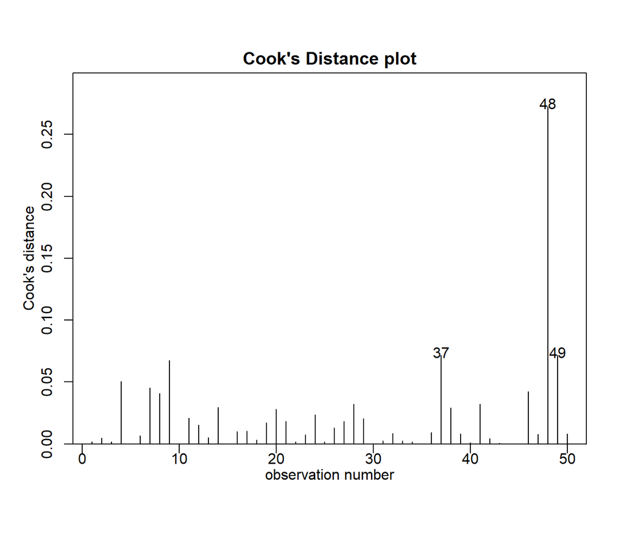

```r
cooks20x(weatherExp1.lm)
```

```r
weatherExp2.lm=lm(ApparentTemperatureC~Humidity, data=weather2[-49,])
summary(weatherExp2.lm)
```

```
##
## Call:
## lm(formula = ApparentTemperatureC ~ Humidity, data = weather2[-49,
##     ])
##
## Residuals:
##      Min       1Q   Median       3Q      Max
## -20.8613  -4.2407   0.0687   5.4447  14.0576
##
## Coefficients:
##             Estimate Std. Error t value Pr(>|t|)
## (Intercept)   39.964      4.256   9.390 2.35e-12 ***
## Humidity     -37.650      5.604  -6.718 2.19e-08 ***
## ---
## Signif. codes:  0 '***' 0.001 '**' 0.01 '*' 0.05 '.' 0.1 ' ' 1
##
## Residual standard error: 7.237 on 47 degrees of freedom
## Multiple R-squared:  0.4899, Adjusted R-squared:  0.479
## F-statistic: 45.14 on 1 and 47 DF,  p-value: 2.188e-08
```

Compared to the first model

```r
summary(weatherExp1.lm)
```

```
##
## Call:
## lm(formula = Humidity ~ ApparentTemperatureC, data = weather)
##
## Residuals:
##      Min       1Q   Median       3Q      Max
## -0.33159 -0.09906  0.00301  0.08472  0.30429
##
## Coefficients:
##                       Estimate Std. Error t value Pr(>|t|)
## (Intercept)           0.898809   0.030892  29.095  < 2e-16 ***
## ApparentTemperatureC -0.013598   0.001929  -7.051 6.15e-09 ***
## ---
## Signif. codes:  0 '***' 0.001 '**' 0.01 '*' 0.05 '.' 0.1 ' ' 1
##
## Residual standard error: 0.1365 on 48 degrees of freedom
## Multiple R-squared:  0.5088, Adjusted R-squared:  0.4985
## F-statistic: 49.71 on 1 and 48 DF,  p-value: 6.151e-09
```

# 7 Conclusion

There did turn out to be a relationship between the Humidity and the Apparent Temperature as well as the Humidity and the real temperature. Going into the project my assumption was that as humidity increased the temperature and apparent temperature would rise as well but the plots from the very beginning proved that to be merely an assumption. The real relationship between either temperature and humidity was a negative linear one, so as humidity grew the temperatures fell.

This is important information to gather becuase how people feel when they are outside will influence everything they do. It will influence whether or not a tourist wants to spend the day shopping or at a pool. It also influences how productive a farmer should anticipate he will be throughout humid parts of the year. The interesting thing found by this data was humidity may actually make the temperature MORE bearable.

## 7.2 Suggest ways to improve model or experiment

This would probably be the only time that I would ever not recommend using the metric system. With Farenheit the values would be further apart and differences would likely be more apparent. Furthermore, it is usually nice to have a large data set but I think it would have served me better to have found a way to look at how the weather factors had changed over time by looking at the past years but I am not that profficient, yet.

# 8 References

[@wikipedia_2019] [@kaggle]